# Application of ComBat-seq on simulated dataset

sequencing depth batch effect

Yuqing Zhang

September 25, 2018

## Intuition for this simulation

Both of the previous two examples deal with batch effect in terms of library composition differences. But batch effect can be in the form of sequencing depth differences as well. This example shows batch effect in terms of the sequencing depth (library size) change. Normalization usually deals with this difference. But is normalization sufficient when library size change is specifically caused by batch? In other words, if samples within batches have relatively similar library sizes, but the library sizes are dramatically different across batch, will that affect downstream analysis, and is it accounted for in common methods?

I’m curious because based on our model, ComBat-seq will not adjust for library size difference - it models the observed library size as constants. If this problem is not sufficiently addressed, then we may want to change our model, maybe include an option to bring average library sizes in batches to the same level.

**NOTE TO SELF:** batch effect in terms of both library size & composition?

## Design of the study

We simulated a **(2000 gene $\times$ 20 sample)** count matrix from negative binomial distributions. The dataset contains **2** batches, with **10** samples in each batch, and **biological effect - a 2-fold change between 2 condition groups**.

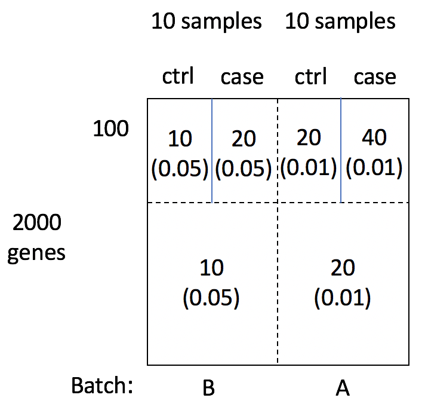

## Simulate dataset

Batch effect in this dataset is in the form of library size change - all genes are higher in mean counts in Batch A compared to Batch B. Both library sizes and dispersions are different across the two batches. We show hiearachical clustering of samples in the dataset based on the unadjusted counts. Samples are clearly clustered by batch - they cluster first by batch (text labels), then by biological condition (colors).

### Distribution of counts in samples

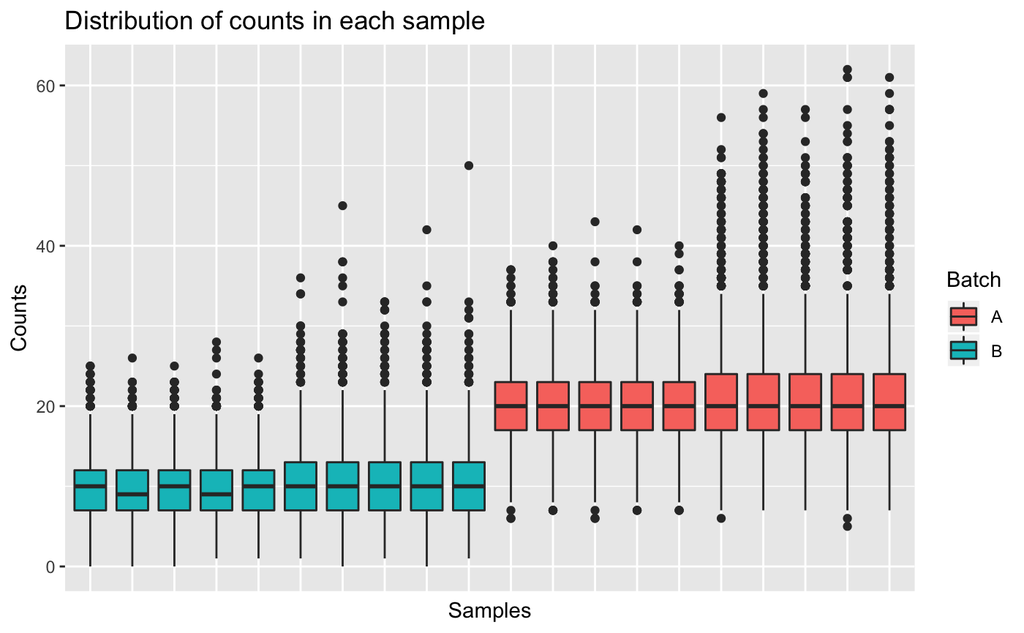

### Batch effect in the dataset

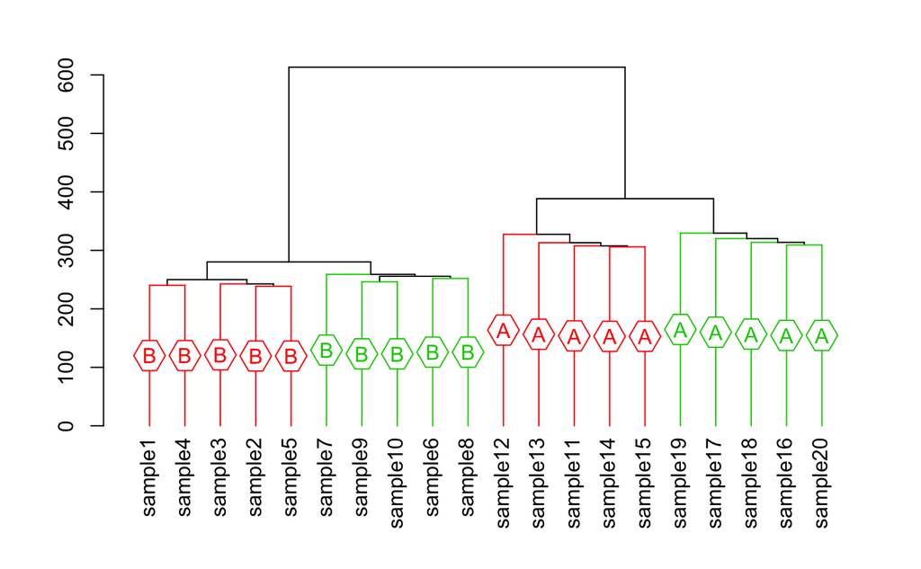

## Apply ComBat-seq

### Adjustment output

We apply ComBat-seq to the above simulated dataset. Some intermediate results of ComBat-seq are printed out to help us better understand how this function works. Running time of ComBat-seq is also recorded.

```
Found 2 batches
Using full model in ComBat-seq.
Adjusting for 1 covariate(s) or covariate level(s)

########  Design matrix  ########
Partial design matrix:
  batchA batchB group1
1      0      1      0
2      0      1      0
3      0      1      0
4      0      1      0
5      0      1      0
6      0      1      1


########  Dispersion  ########
Estimated common dispersion:
[1] 0.010 0.049

Average estimated gene-wise dispersion:
batchA batchB
 0.017  0.059


########  GLM model coefs  ########
Coefficients (model 1):
         batchA    batchB    group1
gene1 -7.734197 -7.571089 0.7052295
gene2 -7.495218 -7.494670 0.5766785
gene3 -7.552764 -7.521750 0.5102226
gene4 -7.677683 -7.804862 0.6716531
gene5 -7.723532 -7.384052 0.5814025
gene6 -7.548627 -7.638589 0.6912995
...
            batchA    batchB       group1
gene1995 -7.691592 -7.704781 -0.017031619
gene1996 -7.637177 -7.916087  0.017809097
gene1997 -7.539142 -7.715643 -0.182520242
gene1998 -7.617925 -7.510806 -0.009782894
gene1999 -7.528577 -7.521370 -0.157297983
```

[output cut: 40 more lines]

```
0.01690682 0.05886264

Posterior average dispersion:
    batchA     batchB
0.01318753 0.05145631

Batch-free mean mu:
[1] 19.98031
[1] 9.900986

Batch-free dispersion phi:
[1] 0.03232192

Running time of ComBat-seq:
Time difference of 33.20891 secs
```

### Visualize adjusted data

Similar as above, we visualize the adjusted counts in each sample (first tab). In the second tab, we can see that after the ComBat-seq adjustment, samples still first cluster by batch. Batch differences are not removed.

#### Distribution of adjusted counts in samples

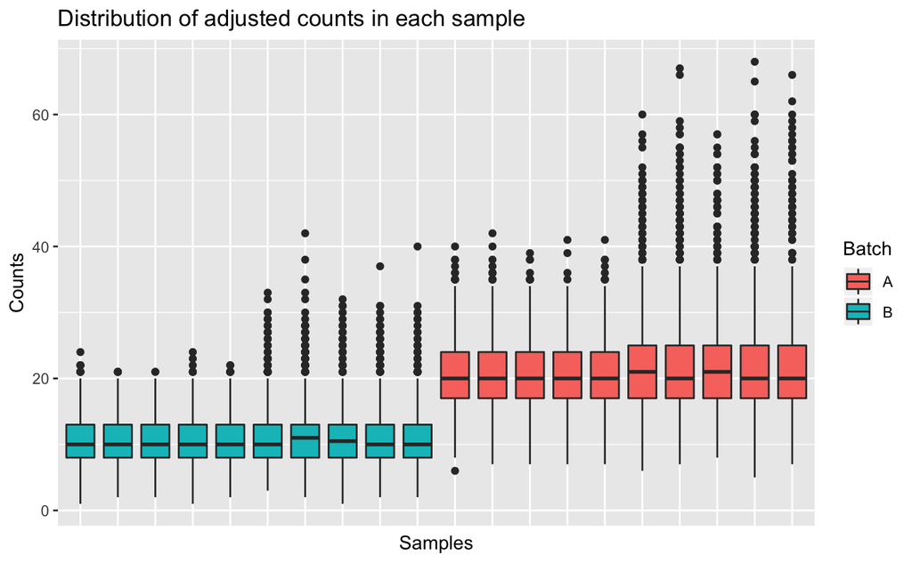

#### Clustering of samples after adjustment

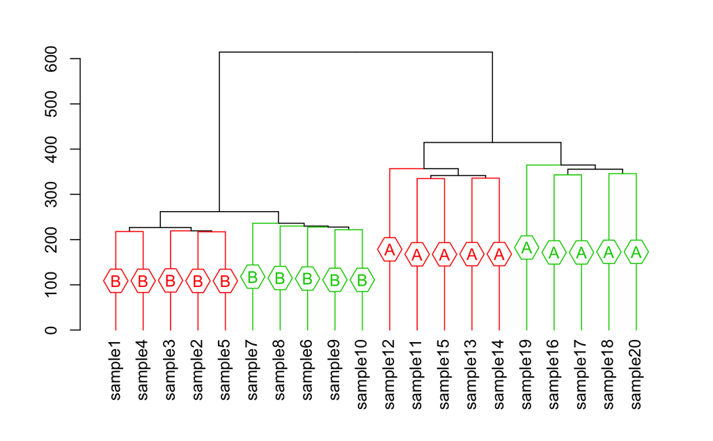

## Is normalization sufficient to correct for batch sequencing depth difference?

In this section we test whether normalization methods correct for sequencing depth / library size differences caused by batch. We apply normalization methods in edgeR and DESeq to see how the normalized counts would look like. As seen below, there’s still some batch differences after scaling counts by the scaling factors calculated by both packages.

### edgeR (TMM)

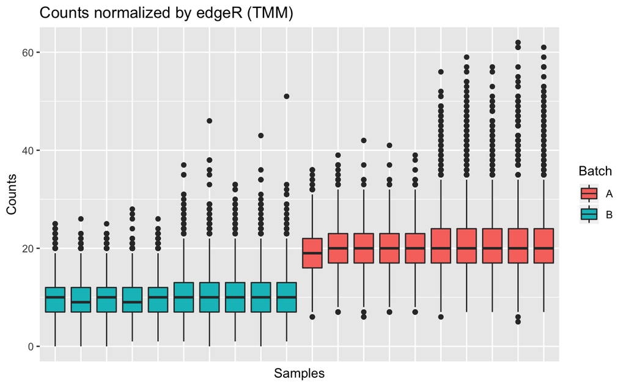

### DESeq2 (Median Ratio Method)

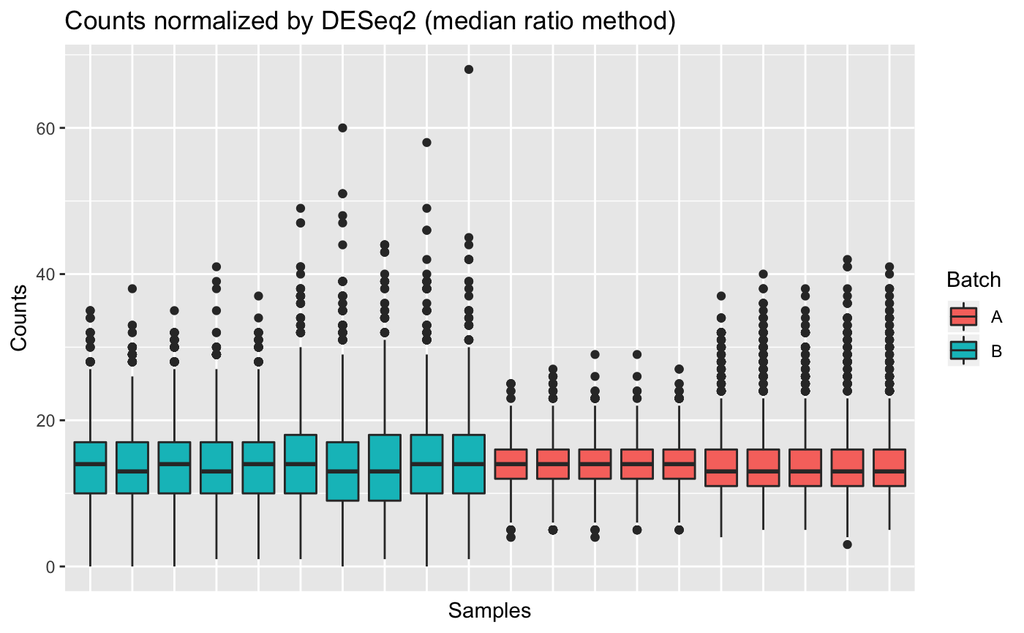

## Differential expression (DE) analysis

In theory, differential expression shouldn’t be affected, at least if we use edgeR or DESeq. Both these models account for library size in their models.

To validate this theory, we try two possible orders of preprocessing: 1) first correct for batch, then normalize the data (adjust sample library size differences through normalization); 2) first normalize the data, then correct for batch. We compare DE results in these two scenarios.

### edgeR

#### ComBat-seq -> Normalize

```
TPR and FPR using edgeR: ComBat-seq -> Normalize
1 0.0032
```

#### Normalize -> ComBat-seq

```
TPR and FPR using edgeR: Normalize -> ComBat-seq
1 0.0032
```

### DESeq2

#### ComBat-seq -> Normalize

```
TPR and FPR using DESeq2: ComBat-seq -> Normalize
1 0.0037
```

#### Normalize -> ComBat-seq

```
TPR and FPR using DESeq2: Normalize -> ComBat-seq
0.99 0.0026
```

## Prediction

Library size difference caused by batch does not matter in differential expression (especially since edgeR and DESeq2 takes library sizes into account in their models). However, ComBat-seq still doesn’t correct for it. Depending on the goal of analysis, we may want to include an option for users to choose whether they want to bring library sizes of different batches to the same level.

To (maybe) find a situation where we want to bring library sizes to the same level, I’m trying a prediction example. In this case, I would generate a test count matrix. 50 of 100 DE genes in test samples are activated in the same way as in the previously simulated dataset (which in this case we use as training set). 50 of non-DE genes are activated in test set but not in training set. All samples in the test set are generated in 1 batch. Biological signals are weaker in the test set than in the training set (a 1.5 fold change in counts). We use simple lasso logistic regression to make predictions, using 1) original counts, 2) counts adjusted by ComBat-seq without library normalization, 3) counts adjusted by ComBat-seq with library normalization (bring all library sizes to their simple average) for training. We generated ROC curves with AUC to measure performance in the three situations.

### Original Counts

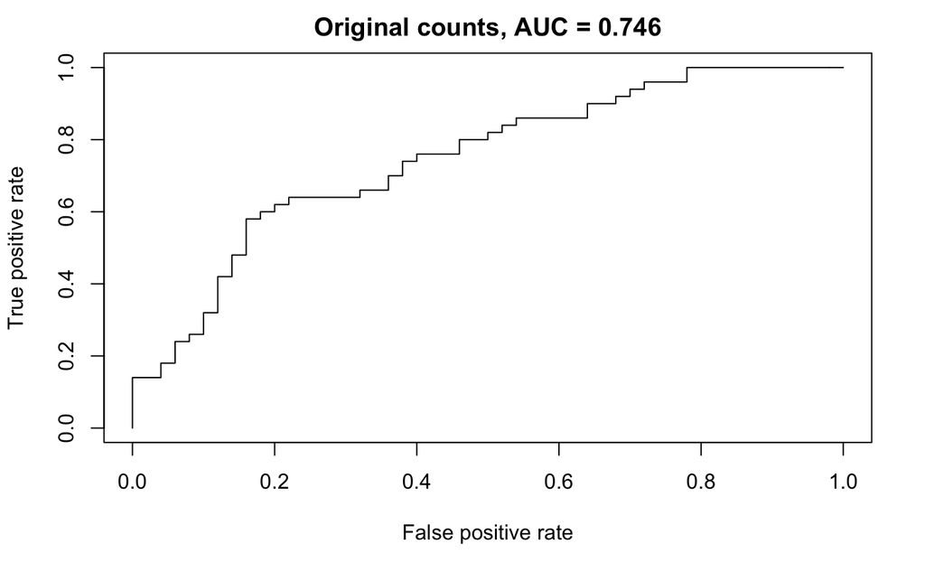

### ComBat-seq WITHOUT library correction

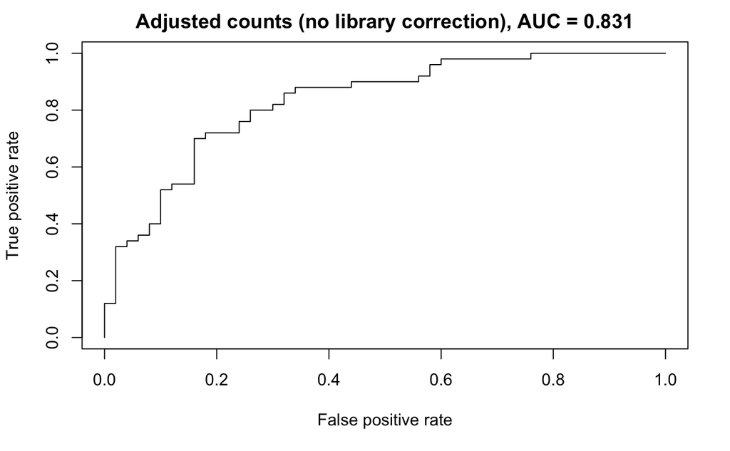

### ComBat-seq WITH library correction

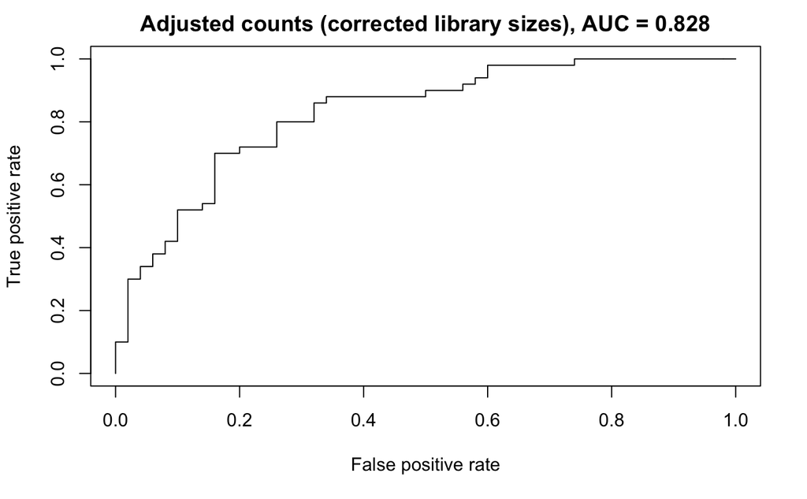

## Thoughts

- Other prediction examples where library size difference could reduce performance of prediction? Maybe an unbalanced study design…
- Simply scaling counts to match sample library sizes to their average may not be a good way to remove library size batch effect.
- Library size is not that important of an issue, especially for differential expression.